# The many roads to a gene-environment interaction

# Background

Gene-environment interactions (GxEs) are of increasing interest for improving genetic discovery, explaining missing heritability and population heterogeneity, and facilitating precision medicine (Gauderman et al. 2017). Their analysis has often been underpowered, but increasing sample sizes and associated computationally efficient software options are beginning to enable larger-scale discovery (Rao et al. 2017; Bi et al. 2019; Westerman et al. 2021).

Thomas and colleagues describe a series of possible definitions of GxE interactions, with different implications for relevant biological mechanisms, statistical detection, and clinical or public health impact (Thomas 2010). Statistical interactions describe any departure from the a model with pure main effects for genetic and environmental terms. Qualitative and quantitative interactions, in which stratified effects differ in direction or magnitude, respectively, are subsets of statistical interactions. “Public health synergy” refers to instances in which two exposures (possibly genetic) jointly influence disease risk in a way that is less than or greater than their individual impacts alone. Finally, a biological interaction describes instances in which the effect of one factor depend on the presence *or absence* of another, at a biological or mechanistic level.

Often, investigators will conduct a GxE analysis based around estimating effects and associated significances for statistical interactions without specifying the underlying phenomenon being sought or clarifying alternative explanations for any observed significant GxEs. Here, we describe five patterns occurring at the biological level that can result in the appearance of a statistical interaction, in hopes that this framework will allow investigators to more clearly state hypotheses and think through alternative explanations for their findings.

Notes:

- In this discussion, we will primarily focus on genotype as a modifier of exposure-outcome associations. However, all concepts also apply for the converse (i.e., the exposure as a modifier of the genotype-outcome relationship) – we will point out some well-recognized examples.
- For simplicity, we will assume continuous outcomes unless otherwise noted.
- We will also assume that there are no confounders of the E-Y relationship, but any of the patterns described below would also hold when analyzing such a confounder as the exposure of interest.

# Phenomena leading to statistical interactions

## Functional

This first category of interaction encompasses the type of functional, molecular-level process that most investigators are likely imagining when conducting a GxE analysis. Here, we might imagine that a genotype, functioning through the function or expression level of some enzyme, modifies the function of a pathway that mediates the E-Y relationship. Most exposures used in GxE analysis, including human behaviors, environmental exposures, and physiological states (such as BMI and biological sex), ultimately impact health outcomes and biomarkers through intermediate or mediating molecular quantities. We can imagine the effect modification by genotype occurring either upstream of this mediating quantity (“mediated moderation”) or downstream of it (Preacher, Rucker, and Hayes 2007).

Numerous functional GxE effects have been reported in the literature, but we highlight two illustrative examples here. Variants in the *ERCC2* gene, involved in DNA damage repair, appear to modify the effect of smoking on lung cancer (Zhou et al. 2002). This is an example of moderated mediation, in which smoking induces lung DNA damage (the molecular mediator), which then impacts lung cancer differentially based on *ERCC2*-related DNA repair capacity (the functional interaction). In another domain, phenylketonuria is a classic diet-related GxE example, where polymorphisms in the *PAH* gene reduce or abolish the ability of its protein product to metabolize the amino acid phenylalanine in the liver (Williams, Mamotte, and Burnett 2008). This is an example of mediated moderation, in which the functional interaction with involves the exposure itself (the dietary amino acid phenylalanine), but ultimately impacts clinical symptoms (primarily cognitive) via changes in circulating phenylalanine. (**I’m starting to think that using these examples to demonstrate the Med Mod vs. Mod Med distinction is a bit of a stretch, and maybe unnecessary.**)

Unlike dietary phenylalanine, for which the relevant metabolic pathways are well-characterized, many high-level exposures (e.g., physical activity or dietary patterns) have more complicated and pleiotropic biological effects. Approaches incorporating molecular-level GxE tests (e.g., with metabolomic exposures (Moore et al. 2019)) may be helpful in resolving the molecular quantities involved. Nonetheless, such cases, for which the relevant biological pathways are less clear, require additional care in considering some of the alternative explanations for any observed GxE discussed below.

We also take this opportunity to consider the terminology used by different authors and in different contexts in this space. Specifically, we seek to draw a distinction between concepts that refer to mechanistic, biological, or functional effects in which specific metabolites, proteins, or other molecular quantities ultimately interact with each other at a molecular level, such that the activity of one pathway or process is modulated by the presence of another. For the balance of this article, we will use the term “functional” to refer to such a situation. Though we believe that “mechanistic” may be an equally appropriate term for such a phenomenon, we want to avoid confusion with the public health-relevant sense in which it is used by VanderWeele and Knol (related more closely to the sufficient cause framework) (VanderWeele and Knol 2014).

**More notes on the terminology question:**

- “Functional” interaction: relevant G and E biological pathways ultimately physically interact at the molecular level
- “Mechanistic” interaction: to me this should be a synonym for “functional”, but used by VanderWeele to refer to something entirely separate (a binary outcome that appears with the presence of both of two exposures, but not only one by itself)
- “Biological” interaction: may or may not be a useful term to be used in the family of what we call functional interactions here
- Statistical interaction: the estimated effect of a product term in a regression
- Moderated mediation vs. mediated moderation (is discussion of this distinction important here, or maybe getting out of scope?)

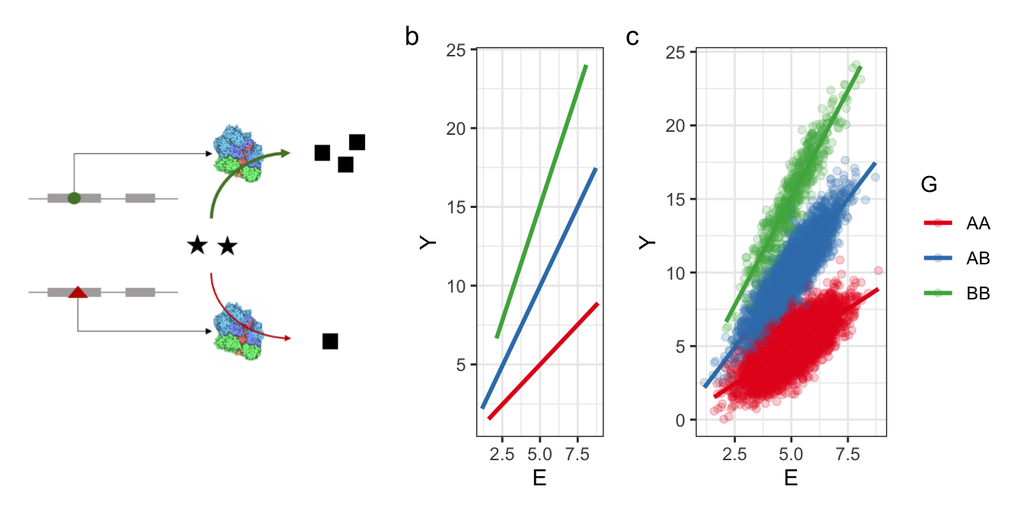

## Nonlinear mediator

In this case, both G and E impact the same pathway or mediator M, which itself has a nonlinear relationship with Y. Due to the genetic main effect, genotype groups will differ in their mean value of M. Due to the nonlinearity of the M-Y relationship, any nonzero main effect on M of another variable (in this case, E) will translate into changes in Y to a different degree. This type of phenomenon may be clinically relevant or artifactual, depending on the hypothesis and relationship of the outcome to clinical decision-making thresholds.

As an example of the latter (binary outcome) situation, a series of studies has explored the joint contribution of genetic and dietary effects on choline sufficiency in postmenopausal women (Fischer et al. 2010). Choline sufficiency functions as a roughly binary variable in the sense that, once an individual has a sufficient choline supply, additional choline will not be beneficial in preventing choline-related organ dysfunction. Though dietary choline absorption and endogenous choline production occur via largely separate pathways that don’t depend on each other directly, they both contribute to the same biological pool. In postmenopausal women with certain variation in the *PEMT* gene (required for endogenous choline production), choline production is substantially reduced, such that these women require additional choline from diet or supplementation to avoid organ dysfunction. A GxE ultimately results, in which reductions in organ dysfunction are expected in postmenopausal women with *PEMT*-reducing allele but will have little effect in others.

We note that this inherent nonlinearity for binary outcomes is fundamentally related to the choice of scale in assessing interactions (additive versus multiplicative). Additive interaction analysis is particularly useful for detecting instances in which G and E contribute additively to an underlying liability that manifests as a binary outcome due to thresholding (whether biological or due to clinical cutoffs). Thus, additive interaction may be relevant for public health applications even when there is no functional interaction of the type that would produce a significant multiplicative interaction (i.e., of the product term in a logistic regression) (VanderWeele and Knol 2014). (**Opportunity to (1) better understand, and (2) clarify terminology with respect to the term “mechanistic” as used by VanderWeele and others. They use it to refer to instances in which the manifestation of a binary outcomes requires the presence of multiple exposures rather than just one, whereas it seems to me that the word better describes a “functional” interaction as discussed above, which is almost the opposite in that it is better detected by a multiplicative interaction**).

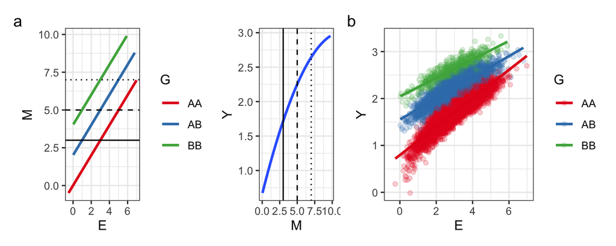

## Heterogeneous variability / vQTL

Here, some G or E directly modifies the *variability*, rather than the mean, of Y while the other explains a consistent *proportion* of the variability in Y. When the variability modifier is genetic, it is often referred to as a variance-quantitative trait locus (vQTL). If some E has a consistent effect on the location of Y within its distribution (i.e., its quantile), its linear effect estimate will be larger in a more variable genotype group (when assessed on the original outcome scale).

Domingue and colleagues describe this scenario as a scaling model (Domingue et al. 2022). Using the UK Biobank dataset, they find a series of genetic variants that associate more strongly with BMI in individuals born later in time. However, they proceed to show evidence that these variants may confer a general sensitivity to environmental influences (and thus a greater BMI variability) rather than a birth year-specific modifying effect.

Other, similar non-specific interaction effects have also been described. For example, quantile-specific heritability is a phenomenon in which genetic effects on a phenotype differ depending on the location in that phenotype’s distribution (Williams 2012, Williams 2020). Such effects will produce a “non-specific” GxE for any exposure having a substantial main effect on the outcome (and thus shifting the location of that phenotype within its distribution).

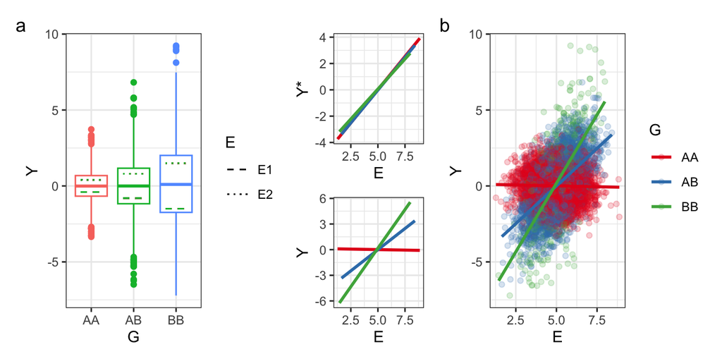

## Heterogeneous measurement

Measurement error in either E or Y decreases the estimated magnitude of any true association between the two. So, if G associates with the precision of measurement of E *or* Y, then any nonzero E-Y association will appear stronger in the genotype group with better measurement, inducing a statistical GxE. Importantly, this issue arises when G associates with the degree of noise in measurement, rather than a directional bias (**Anything concrete we can say about what happens when G associates with biased, but not less-precise, measurement? Point for discussion related to the vitamin D example below.**).

For example, certain genotypes could lead to more accurate self-reporting of exposures (**example?**). As an example of G impacting outcome measurement, studies investigating vitamin D-binding protein (DBP) have established that the chemistry of some immunoassays leads to bias in DBP measurement (Nielson et al. 2016). In another example, race-associated differences in skin pigmentation (caused by underlying genetic factors) have been shown to lead to decreased pulse oximeter performance in measuring blood oxygen saturation, with implications for disparities in healthcare delivery (Gottlieb et al. 2022).

This category captures a range of related phenomena. For some outcomes of interest, there may be floor or ceiling effects that affect measurement of Y; here, a strong genetic main effect could indirectly increase measurement error by pushing the mean of Y to more extreme values (Molenaar et al. 2013; Tucker-Drob 2009). Additionally, this concern can even extend to the realm of regression covariates: genotype-associated covariate measurement error can affect the “success” of adjustment and thus E effect estimates across genotype groups (**Is this true for interactions if a GxCovariate interaction isn’t explicitly modeled?**) (Spiegelman, McDermott, and Rosner 1997; Thomas, Stram, and Dwyer 1993).

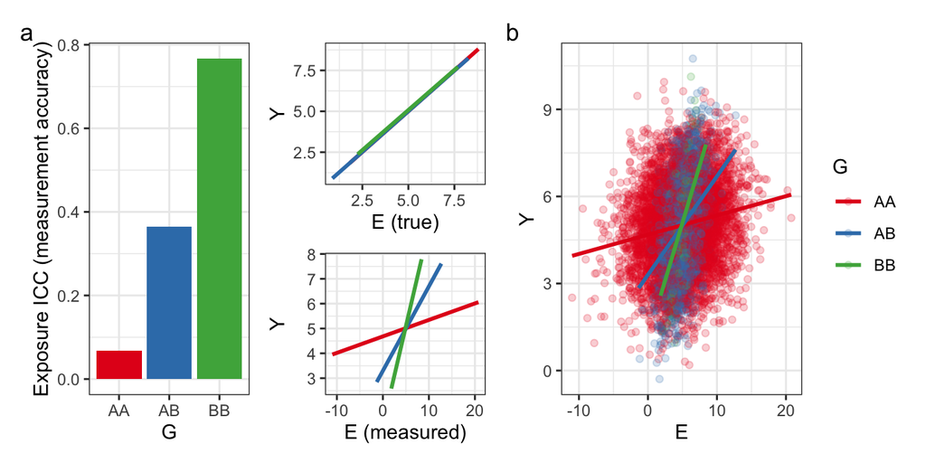

## G-E correlation plus nonlinearity

Finally, statistical interactions can appear when an exposure is (1) under genetic control (i.e., correlated with G) and (2) related nonlinearly with Y. In this case, the genetic effect alters the mean E across genotype groups and the nonlinearity of the E-Y relationship leads to different effect estimates in these different places on the exposure spectrum.

(**Thoughts on an example here?**)

This general phenomenon leads to the inflation often observed in genome-wide interaction studies when regression models are misspecified with respect to the E-Y relationship. In such a case, random G-E correlations genome-wide combine with the nonlinear E-Y relationship to produce statistical evidence of GxE. Though these apparent interaction effects are random and typically small, in aggregate they produce a systematic departure of genome-wide interaction p-values from the uniform distribution expected under the null hypothesis (Voorman et al. 2011).

A related phenomenon combines this concern with the previous (related to heterogeneous measurement), this time with respect to genotype. As observed by Dubridge and Fletcher, spurious GxEs can appear due to a combination of G-E correlation and use of a non-causal (tag) variant (Dudbridge and Fletcher 2014). Here, as in many genotyping array-based studies, a tag variant acts an an imperfect proxy of some causal variant, and is often a biased measurement of this causal variant due to differing allele frequencies. When G and E are correlated, E becomes associated with the fidelity of “measurement” of the underlying causal variant, ultimately leading to a differential genetic effect across levels of E. Put another way, such an interaction appears due to a combination of G-E correlation and measurement error in G.

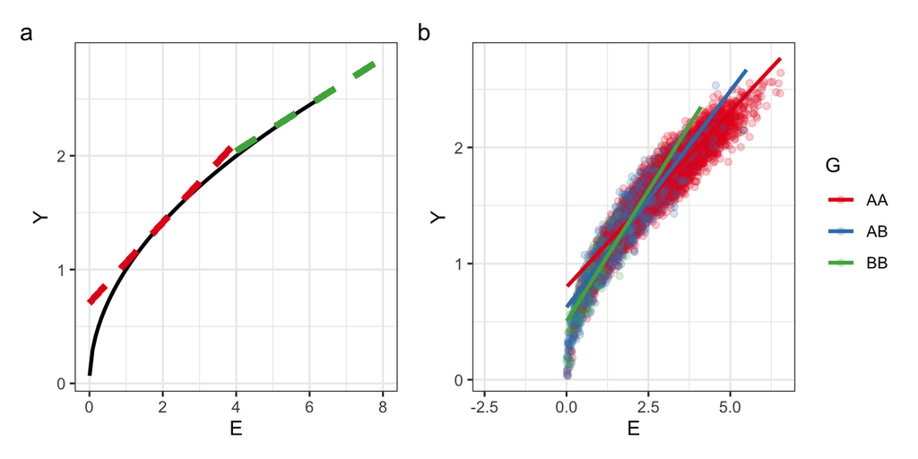

# Recommendations

In this section, we expand on some specific considerations in recognition of the phenomena described above.

- Is a continuous outcome important in relation to a clinical cutoff? If so, any interaction manifesting on the scale of this outcome as typically measured will be important. For example, it is likely that there is is at least some nonlinearity in the increased cardiovascular disease risk associated with LDL-cholesterol. Nonetheless, specific cutoffs are established for the initiation of cholesterol-lowering medication and targets for therapy. In such cases, linear interactions that are observed on the additive scale (as typically tested by regression product terms) will be clinically important even if they do not show up on other scales (such as a multiplicative scale in logistic regression). (**I know this is sloppy writing/thinking here but hopefully this communicates the seed of the idea.**)
- Is a specific interaction (i.e., one that corresponds only to the exposure being tested) important? This will involve both consideration of potential biological mechanisms involved and influence sensitivity analysis. Upon finding a GxE, statistical tools are available to test for evidence of general vQTL effects independent of a specific GxE (Domingue et al. 2022). Furthermore, databases of vQTLs are beginning to appear, in which investigators can look for prior evidence of variance modification at genetic variants of interest (Westerman et al. 2022), though as noted above, these may appear secondary to a specific GxE rather than indicating a general variance modulation effect.
- Any note about polygenic scores and their use as the G in GxE analysis? They improve power but make interpretation (and the considerations above) that much more complicated and opaque. It could be useful to note that their use makes evaluating these various phenomena more difficult (e.g., how to think about whether a PRS acts as a “true” vQTL, or whether it influences measurement quality?). However, this might be out of scope / distracting rather than helpful.
- More examples here would be good – these recommendations constitute the payoff of this review.

The considerations described above are certainly not exhaustive, and we encourage investigators of GxEs to carefully consider their hypothesis in both designing and interpreting experiments.

# Appendix: Simulation setup

1. Simulate G with MAF=0.25: $G \sim binom(2, 0.25)$ ($N_{sims}$ = 10,000)
2. Simulate E, M (where applicable), and Y as follows:

[output not shown]

3. Test for statistical interaction using the following regression model:
   $$Y \sim G + E + G*E$$

Regression results from simulations

| term | estimate | p.value |
| --- | --- | --- |
| **Functional** |  |  |
| g | 0.103 | 0.224 |
| e | 1.021 | 0.000 |
| g:e | 0.980 | 0.000 |
| **Nonlinear mediator** |  |  |
| g | 0.688 | 0.000 |
| e | 0.299 | 0.000 |
| g:e | -0.064 | 0.000 |
| **Heterogeneous variability / vQTL** |  |  |
| g | -4.792 | 0.000 |
| e | -0.011 | 0.482 |
| g:e | 0.965 | 0.000 |
| **Heterogeneous measurement** |  |  |
| g | -1.462 | 0.000 |
| e_m | 0.065 | 0.000 |
| g:e_m | 0.294 | 0.000 |
| **G-E correlation plus nonlinearity** |  |  |
| g | -0.144 | 0.000 |
| e | 0.305 | 0.000 |
| g:e | 0.063 | 0.000 |

# Questions and expansions

- More types/phenomena?
- Other options for nonlinear transform (in diagrams/simulations) that accommodate negative exposure

# References

Bi, Wenjian, Zhangchen Zhao, Rounak Dey, Lars G. Fritsche, Bhramar Mukherjee, and Seunggeun Lee. 2019. “A Fast and Accurate Method for Genome-Wide Scale Phenome-Wide g × e Analysis and Its Application to UK Biobank.” *The American Journal of Human Genetics* 105 (December): 1182–92. https://doi.org/10.1016/j.ajhg.2019.10.008.

Domingue, Benjamin W., Klint Kanopka, Travis T. Mallard, Sam Trejo, and Elliot M. Tucker-Drob. 2022. “Modeling Interaction and Dispersion Effects in the Analysis of Gene-by-Environment Interaction.” *Behavior Genetics* 52. https://doi.org/10.1007/s10519-021-10090-8.

Dudbridge, Frank, and Olivia Fletcher. 2014. “Gene-Environment Dependence Creates Spurious Gene-Environment Interaction.” *American Journal of Human Genetics* 95. https://doi.org/10.1016/j.ajhg.2014.07.014.

Eaves, Lindon J. 2006. “Genotype × Environment Interaction in Psychopathology: Fact or Artifact?” *Twin Research and Human Genetics* 9. https://doi.org/10.1375/twin.9.1.1.

Fischer, Leslie M., Kerry Ann Da Costa, Lester Kwock, Joseph Galanko, and Steven H. Zeisel. 2010. “Dietary Choline Requirements of Women: Effects of Estrogen and Genetic Variation.” *American Journal of Clinical Nutrition* 92. https://doi.org/10.3945/ajcn.2010.30064.

Gauderman, W. James, Bhramar Mukherjee, Hugues Aschard, Li Hsu, Juan Pablo Lewinger, Chirag J. Patel, John S. Witte, et al. 2017. “Update on the State of the Science for Analytical Methods for Gene-Environment Interactions.” *American Journal of Epidemiology* 186 (October): 762–70. https://doi.org/10.1093/aje/kwx228.

Gottlieb, Eric Raphael, Jennifer Ziegler, Katharine Morley, Barret Rush, and Leo Anthony Celi. 2022. “Assessment of Racial and Ethnic Differences in Oxygen Supplementation Among Patients in the Intensive Care Unit.” *JAMA Internal Medicine* 182 (August): 849. https://doi.org/10.1001/jamainternmed.2022.2587.

Molenaar, Dylan, Sophie Van Der Sluis, Dorret I. Boomsma, Claire M. A. Haworth, John K. Hewitt, Nicholas G. Martin, Robert Plomin, Margaret J. Wright, and Conor V. Dolan. 2013. “Genotype by Environment Interactions in Cognitive Ability: A Survey of 14 Studies from Four Countries Covering Four Age Groups.” *Behavior Genetics* 43. https://doi.org/10.1007/s10519-012-9581-7.

Moore, Rachel, Francesco Paolo Casale, Marc Jan Bonder, Danilo Horta, Lude Franke, Inês Barroso, and Oliver Stegle. 2019. “A Linear Mixed-Model Approach to Study Multivariate Gene–Environment Interactions.” *Nature Genetics* 51 (January): 180–86. https://doi.org/10.1038/s41588-018-0271-0.

Nielson, Carrie M., Kerry S. Jones, Rene F. Chun, Jon M. Jacobs, Ying Wang, Martin Hewison, John S. Adams, et al. 2016. “Free 25-Hydroxyvitamin d: Impact of Vitamin d Binding Protein Assays on Racial-Genotypic Associations.” *Journal of Clinical Endocrinology and Metabolism* 101. https://doi.org/10.1210/jc.2016-1104.

Preacher, Kristopher J., Derek D. Rucker, and Andrew F. Hayes. 2007. “Addressing Moderated Mediation Hypotheses: Theory, Methods, and Prescriptions.” *Multivariate Behavioral Research* 42. https://doi.org/10.1080/00273170701341316.

Rao, D. C., Yun J. Sung, Thomas W. Winkler, Karen Schwander, Ingrid Borecki, L. Adrienne Cupples, W. James Gauderman, Kenneth Rice, Patricia B. Munroe, and Bruce M. Psaty. 2017. “Multiancestry Study of Gene-Lifestyle Interactions for Cardiovascular Traits in 610 475 Individuals from 124 Cohorts: Design and Rationale.” *Circulation: Cardiovascular Genetics* 10. https://doi.org/10.1161/CIRCGENETICS.116.001649.

Spiegelman, Donna, Aidan McDermott, and Bernard Rosner. 1997. “Regression Calibration Method for Correcting Measurement-Error Bias in Nutritional Epidemiology.” In *American Journal of Clinical Nutrition*. Vol. 65. https://doi.org/10.1093/ajcn/65.4.1179S.

Thomas, D., D. Stram, and J. Dwyer. 1993. “Exposure Measurement Error: Influence on Exposure-Disease Relationships and Methods of Correction.” *Annual Review of Public Health*. https://doi.org/10.1146/annurev.pu.14.050193.000441.

Tucker-Drob, Elliot M. 2009. “Differentiation of Cognitive Abilities Across the Life Span.” *Developmental Psychology* 45. https://doi.org/10.1037/a0015864.

VanderWeele, Tyler J., and Mirjam J. Knol. 2014. “A Tutorial on Interaction.” *Epidemiologic Methods* 3. https://doi.org/10.1515/em-2013-0005.

Voorman, Arend, Thomas Lumley, Barbara McKnight, and Kenneth Rice. 2011. “Behavior of QQ-Plots and Genomic Control in Studies of Gene-Environment Interaction.” Edited by Stacey Cherny. *PLoS ONE* 6 (May): e19416. https://doi.org/10.1371/journal.pone.0019416.

Westerman, Kenneth E, Timothy D Majarian, Franco Giulianini, Dong-Keun Jang, Jenkai Miao, Jose C Florez, Han Chen, et al. 2022. “Variance-Quantitative Trait Loci Enable Systematic Discovery of Gene-Environment Interactions for Cardiometabolic Serum Biomarkers.” *Nature Communications* 13: 3993. https://doi.org/10.1038/s41467-022-31625-5.

Westerman, Kenneth E, Duy T Pham, Liang Hong, Ye Chen, Magdalena Sevilla-González, Yun Ju Sung, Yan V Sun, Alanna C Morrison, Han Chen, and Alisa K Manning. 2021. “GEM: Scalable and Flexible Gene–Environment Interaction Analysis in Millions of Samples.” *Bioinformatics*, May. https://doi.org/10.1093/bioinformatics/btab223.

Williams, Robin A, Cyril D S Mamotte, and John R Burnett. 2008. “Phenylketonuria: An Inborn Error of Phenylalanine Metabolism.” *The Clinical Biochemist. Reviews* 29.

Zhou, Wei, Geoffrey Liu, David P. Miller, Sally W. Thurston, Li Lian Xu, John C. Wain, Thomas J. Lynch, Li Su, and David C. Christiani. 2002. “Gene-Environment Interaction for the ERCC2 Polymorphisms and Cumulative Cigarette Smoking Exposure in Lung Cancer.” *Cancer Research* 62.